# VLE engagement and learning outcome

This analysis explores the relations between students’ engagement with the virtual learning environment (VLE), students’ demographic characteristics and learning outcome.

### Data processing

```r
library(dplyr)
library(oulad)
library(ggplot2)
data(course)
data(assessment)
data(student)
data(vle)
data(student_assessment)
data(student_vle)
data(student_registration)
student_vle_unique<- student_vle %>% group_by(code_module,code_presentation,id_student,id_site,date) %>% summarise(sum_click=sum(sum_click))
rm(student_vle)
#Get student-level info across multiple datasets
tmaRatio<- assessment %>% filter(assessment_type!="Exam") %>% group_by(code_module,code_presentation) %>% summarise(tma=mean(assessment_type=="TMA"))

moduleStudentClick<-student_vle_unique %>% group_by(code_module,code_presentation,id_student) %>% summarise(meanDailyClick=sum(sum_click)/n_distinct(date))
mergedData<- merge(student,tmaRatio,by=c("code_module","code_presentation"))
mergedData<- merge(mergedData,moduleStudentClick,by=c("code_module","code_presentation","id_student"))

mergedData$code_module_category<-"Social sciences"
mergedData$code_module_category[mergedData$code_module %in% c("CCC","DDD","EEE","FFF")]<-"STEM"
#re-code final result and education level as ordered factor variables
uniq_levels<-unique(mergedData$highest_education)
mergedData$highest_education<-factor(mergedData$highest_education,levels=uniq_levels[c(5,2,3,1,4)],ordered=T)
mergedData$final_result<-factor(mergedData$final_result,levels=c("Withdrawn","Fail","Pass","Distinction"),ordered = T)
```

### Mean daily click vs. final result

Students that pass the class or get distinction have higher mean daily click on the VLE compared to students that fail or withdraw.

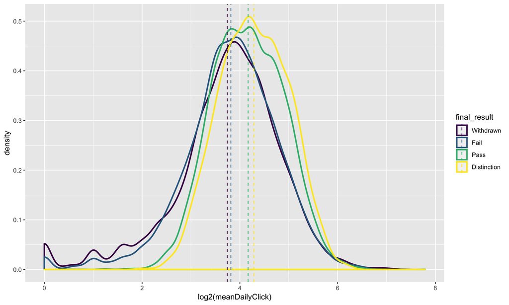

```r
library(dplyr)
library(ggplot2)
mu<- mergedData %>% group_by(final_result) %>% summarise(meanClick=mean(log2(meanDailyClick)))
ggplot(data=mergedData,aes(x=log2(meanDailyClick))) + geom_density(aes(color=final_result),alpha=0.3,size=1) + geom_vline(data=mu, aes(xintercept=meanClick, color=final_result),linetype="dashed")
```

For STEM classes, young (<35) female students have lower mean daily clicks than young male students. The difference is not present in social sciences, and is much smaller between older female vs. male students in STEM classes.

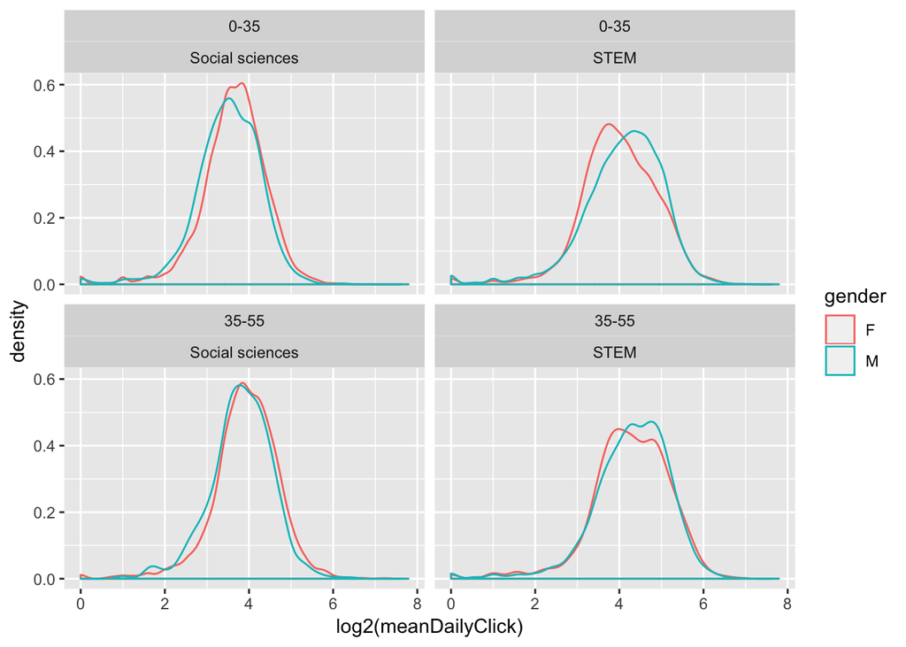

```r
ggplot(data=mergedData[mergedData$age_band!="55<=",],aes(x=log2(meanDailyClick))) + geom_density(aes(color=gender)) + facet_wrap(age_band~code_module_category)
```

### Number of days student interact with the VLE and final result

For each student in each module presentation, calculate how many days it clicked the online learning material.

```r
moduleStudentDailyClick<-student_vle_unique %>% group_by(code_module,code_presentation,id_student,date) %>% summarise(totalClick=sum(sum_click)) %>% summarise(daysClicked=n_distinct(date))
mergedData<-merge(mergedData,moduleStudentDailyClick,by=c("code_module","code_presentation","id_student"))
```

Number of days students interact with the VLE is independent of mean daily clicks - no strong correlation between the two variables.

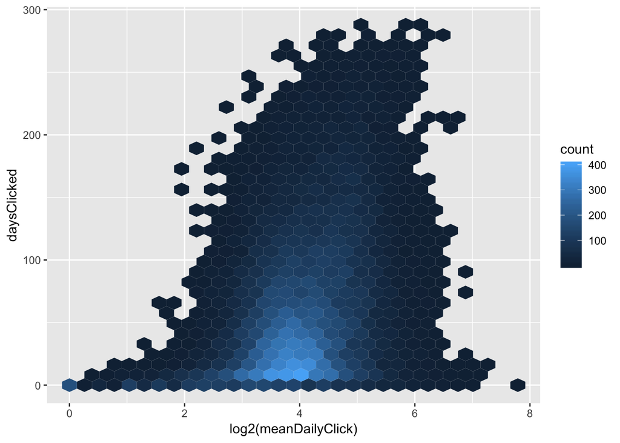

```r
ggplot(data=mergedData,aes(x=log2(meanDailyClick),y=daysClicked)) + geom_hex()
```

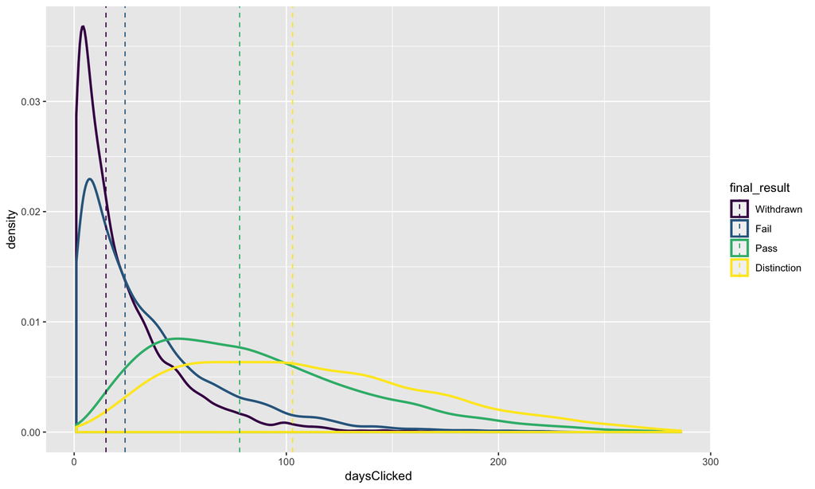

```r
mu<- mergedData %>% group_by(final_result) %>% summarise(meanDaysClick=median(daysClicked))
ggplot(data=mergedData,aes(x=daysClicked)) + geom_density(aes(color=final_result),alpha=0.3,size=1) + geom_vline(data=mu, aes(xintercept=meanDaysClick, color=final_result),linetype="dashed")
```

Female and male students across age groups engage with the VLE at similar frequency throughout both social science and STEM classes. This result is different from mean daily clicks, where young (<35) female have lower mean daily clicks in STEM classes.

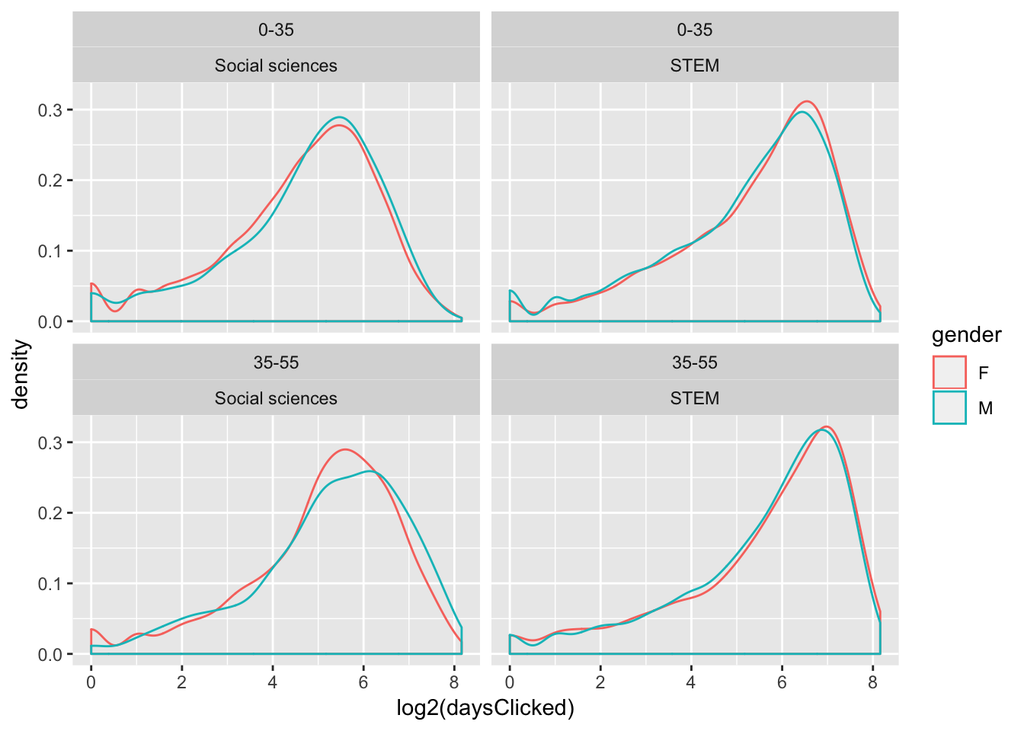

```r
ggplot(data=mergedData[mergedData$age_band!="55<=",],aes(x=log2(daysClicked))) + geom_density(aes(color=gender)) + facet_wrap(age_band~code_module_category)
```